# Weight Lifting Prediction

Samuel Omole

22/01/2021

## Project background

People regularly quantify how much of a particular activity they do, but they rarely quantify how well they do it. In this project, the goal is to use data from accelerometers on the belt, forearm, arm, and dumbell of six participants to predict how well a weight lifting exercise was performed. They were asked to perform barbell lifts correctly and incorrectly in 5 different ways. More information is available here http://groupware.les.inf.puc-rio.br/har under the section on the Weight Lifting Exercise Dataset.

## Load required libraries

The main libraries used in this project include tidyverse, caret and corrplot. The caret and tidyverse packages are very useful in this case as other libraries are embedded within them.

## Reading the files

The validation data will be set aside and will basically serve as an hold-out sample which will be used to determine the accuracies of the predictive models used in this project. Meanwhile, the train_set observations will be split into the actual training and test sets.

```r
train_set <- read.csv("pml-training.csv")
validation <- read.csv("pml-testing.csv")
```

## Partitioning the train_set data

In this section, classe is the response variable which is to be predicted. The data is split so that 70% of data is used for training. The split results in the training and testing data as the shown below.

```r
y <- train_set$classe
test_index <- createDataPartition(y, times = 1, p = 0.7, list = FALSE)
training <- train_set[test_index, ]
testing <- train_set[-test_index, ]
```

## Data preprocessing

This stage involves observing and making valuable plots to gain insight into the nature of the predictor variables. The str function shows there are 13737 observations with 160 columns in the training data while the test data has 5885 observations but the same number of columns as is expected. The function also shows there are a lot of NAs which are not useful for prediction purposes. Based on this, columns which are predominantly NAs will be removed as part of the preprocessing stage. Usually, predictors with weak variability are removed from teh data as they may cause the fit to be unstable. The nearZeroVar function helps perform this function in R by flagging problematic columns.

```r
nzv <- nearZeroVar(training)
training <- training[, -nzv]
testing <- testing[, -nzv]
```

```r
isna <- sapply(training, function(x) mean(is.na(x)))
```

```r
table(isna)
```

```
## isna
##                 0 0.979253112033195
##                59                42
```

Applying isna to the training and test data is done below. Doing this now retains 59 columns for both the training and testing data.

```r
training <- training[, isna == 0]
testing  <- testing[, isna == 0]
```

The structure of the data also shows that the first 5 columns are mainly identification purposes and bear no significance to the response. These are columns are removed using the chunk below.

```r
training <- training[,-c(1:5)]
testing <- testing[,-c(1:5)]
```

Finally, checking for highly correlated predictors, it can be seen that there aren’t too many highly correlated predictors. This means further analyses, like the principal component analysis, are not required. The code is written below.

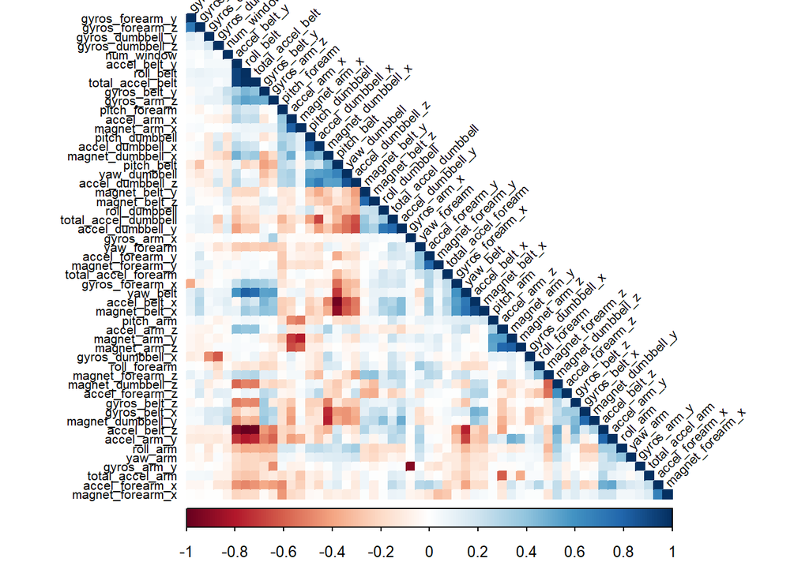

Plot of correlation between predictors

```r
training_cor <-  cor(training[,-54]) # removing the classe column
corrplot(training_cor, method = "color", type = "lower", order = "hclust",
         tl.col = "black", tl.srt = 45, tl.cex = 0.65)
```

## Prediction methods

### Using decision tree

```r
training$classe <- factor(training$classe)
testing$classe <- factor(testing$classe)
train_rpart <- train(classe ~ ., method = "rpart",
                     tuneGrid = data.frame(cp = seq(0, 0.05, len = 25)), data = training)
pred <- predict(train_rpart, testing)
confusionMatrix(pred, testing$classe)
```

```
## Confusion Matrix and Statistics
##
##           Reference
## Prediction    A    B    C    D    E
##          A 1640   25    8    8    3
##          B   16 1064   23    8    7
##          C    3   23  963   20    7
##          D    7   16   24  921   19
##          E    8   11    8    7 1046
##
## Overall Statistics
##
##                Accuracy : 0.9573
##                  95% CI : (0.9519, 0.9624)
##     No Information Rate : 0.2845
##     P-Value [Acc > NIR] : < 2e-16
##
##                   Kappa : 0.946
##
##  Mcnemar's Test P-Value : 0.09647
##
## Statistics by Class:
##
##                      Class: A Class: B Class: C Class: D Class: E
## Sensitivity            0.9797   0.9342   0.9386   0.9554   0.9667
## Specificity            0.9896   0.9886   0.9891   0.9866   0.9929
## Pos Pred Value         0.9739   0.9517   0.9478   0.9331   0.9685
## Neg Pred Value         0.9919   0.9843   0.9871   0.9912   0.9925
## Prevalence             0.2845   0.1935   0.1743   0.1638   0.1839
## Detection Rate         0.2787   0.1808   0.1636   0.1565   0.1777
## Detection Prevalence   0.2862   0.1900   0.1726   0.1677   0.1835
## Balanced Accuracy      0.9846   0.9614   0.9638   0.9710   0.9798
```

### Using random forest

```r
control <- trainControl(method = "cv", number = 10, p = .9) # 10-fold cross-validation with 90% of the data
train_rf <- train(classe ~ ., method = "rf", data = training, trControl = control)
pred1 <- predict(train_rf, testing)
confusionMatrix(pred1, testing$classe)
```

```
## Confusion Matrix and Statistics
##
##           Reference
## Prediction    A    B    C    D    E
##          A 1673    3    0    0    0
##          B    0 1132    2    0    0
##          C    0    3 1024    3    0
##          D    0    1    0  960    1
##          E    1    0    0    1 1081
##
## Overall Statistics
##
##                Accuracy : 0.9975
##                  95% CI : (0.9958, 0.9986)
##     No Information Rate : 0.2845
##     P-Value [Acc > NIR] : < 2.2e-16
##
##                   Kappa : 0.9968
##
##  Mcnemar's Test P-Value : NA
##
## Statistics by Class:
##
##                      Class: A Class: B Class: C Class: D Class: E
## Sensitivity            0.9994   0.9939   0.9981   0.9959   0.9991
## Specificity            0.9993   0.9996   0.9988   0.9996   0.9996
## Pos Pred Value         0.9982   0.9982   0.9942   0.9979   0.9982
## Neg Pred Value         0.9998   0.9985   0.9996   0.9992   0.9998
## Prevalence             0.2845   0.1935   0.1743   0.1638   0.1839
## Detection Rate         0.2843   0.1924   0.1740   0.1631   0.1837
## Detection Prevalence   0.2848   0.1927   0.1750   0.1635   0.1840
## Balanced Accuracy      0.9993   0.9967   0.9984   0.9977   0.9993
```

### Using knn

```r
train_knn <- train(classe ~ ., method = "knn", data = training)
pred2 <- predict(train_knn, testing)
confusionMatrix(pred2, testing$classe)
```

```
## Confusion Matrix and Statistics
##
##           Reference
## Prediction    A    B    C    D    E
##          A 1609   43   10   13   22
##          B   21  992   25   10   22
##          C   18   47  967   74   21
##          D   19   39   15  850   50
##          E    7   18    9   17  967
##
## Overall Statistics
##
##                Accuracy : 0.915
##                  95% CI : (0.9076, 0.922)
##     No Information Rate : 0.2845
##     P-Value [Acc > NIR] : < 2.2e-16
##
##                   Kappa : 0.8925
##
##  Mcnemar's Test P-Value : < 2.2e-16
##
## Statistics by Class:
##
##                      Class: A Class: B Class: C Class: D Class: E
## Sensitivity            0.9612   0.8709   0.9425   0.8817   0.8937
## Specificity            0.9791   0.9836   0.9671   0.9750   0.9894
## Pos Pred Value         0.9481   0.9271   0.8580   0.8736   0.9499
## Neg Pred Value         0.9845   0.9695   0.9876   0.9768   0.9764
## Prevalence             0.2845   0.1935   0.1743   0.1638   0.1839
## Detection Rate         0.2734   0.1686   0.1643   0.1444   0.1643
## Detection Prevalence   0.2884   0.1818   0.1915   0.1653   0.1730
## Balanced Accuracy      0.9701   0.9273   0.9548   0.9284   0.9415
```

### Ensembling

Here, the models were combined using the test data. The accuracy of the resulting fit can, therefore, not be checked using the test data.

```r
ensemble_df <- data.frame(pred = pred, pred1 = pred1, pred2 = pred2, classe = testing$classe)
ensemble_fit <- train(classe ~ ., data = ensemble_df, method = "rf") # using random forest for ensembling
```

## Assessing the predictive capability

```r
predv <- predict(train_rpart, validation) # using the decision tree
predv1 <- predict(train_rf, validation) # using random forest
predv2 <- predict(train_knn, validation) # using knn
ens_df <- data.frame(pred = predv, pred1 = predv1, pred2 = predv2) # creating a dataframe of predictions
ensemble_pred <- predict(ensemble_fit, ens_df) # applying the ensemble_fit
```

Already the random forest produced the highest accuracy was shown already. It is plausible to, therefore, use this model to predict the response of the validation set. While comparing the predictions between model fits showed that the random forest is identical to the ensembling prediction.

```r
mean(predv1==ensemble_pred) # equals 1
```

```
## [1] 1
```

Finally, the **random forest** prediction, predv1, was used and the output is shown below.

```r
predv1
```

```
##  [1] B A B A A E D B A A B C B A E E A B B B
## Levels: A B C D E
```